# An Introduction to Probability using Simulation

Mick Cooney mickcooney@gmail.com

2019-04-08

# 1 Law of Large Numbers

$$\lim_{n \to \infty} \frac{1}{N} \sum f(X_n) \, p(X_n) \to E[f(X)]$$

$$f(x) = x$$

This function gives us expectations for the mean.

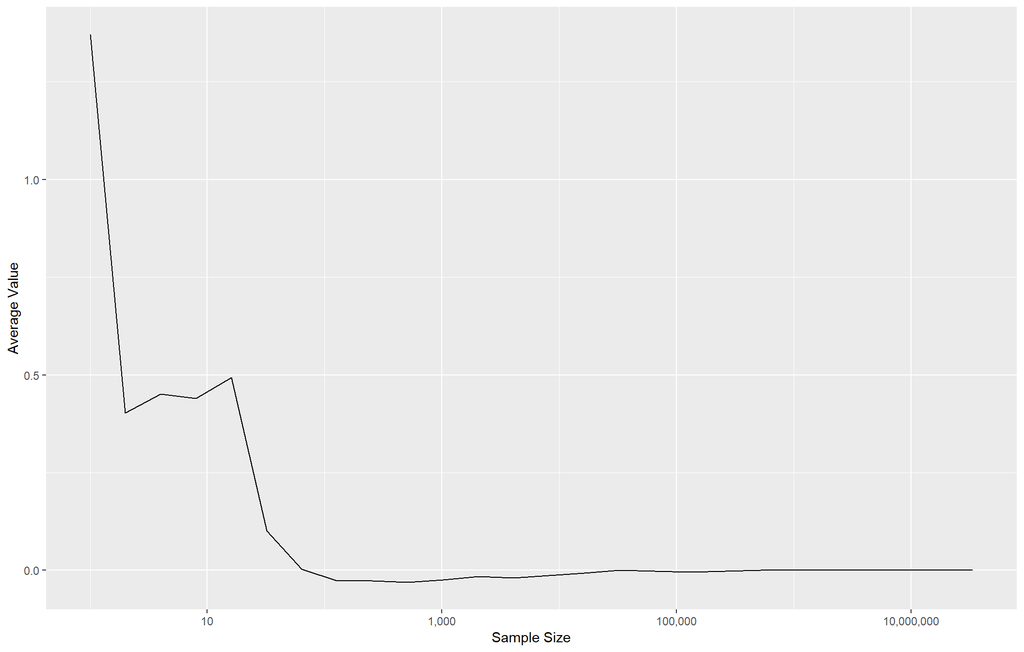

```r
N <- 2^(0:25)

x_vals <- rnorm(max(N), 0, 1)

y_vals <- map_dbl(N, function(i) x_vals[1:i] %>% mean())

ggplot() +
    geom_line(aes(x = N, y = y_vals)) +
    scale_x_log10(labels = comma) +
    xlab("Sample Size") +
    ylab("Average Value")
```

$$f(X) = x^2$$

This function gives us expectations for the variance.

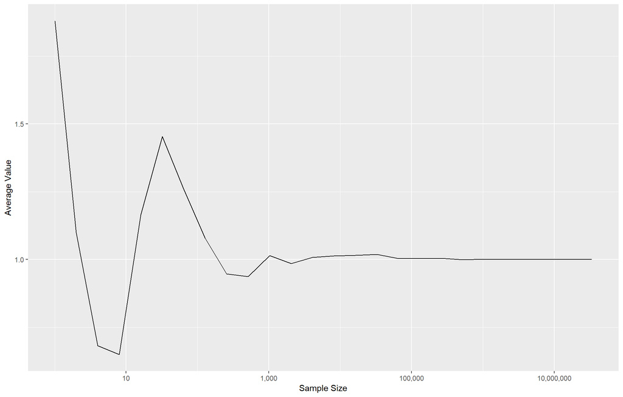

```r
y_vals <- map_dbl(N, function(i) { (x_vals[1:i])^2 %>% mean() })

ggplot() +
    geom_line(aes(x = N, y = y_vals)) +
    scale_x_log10(labels = comma) +
    xlab("Sample Size") +
    ylab("Average Value")
```

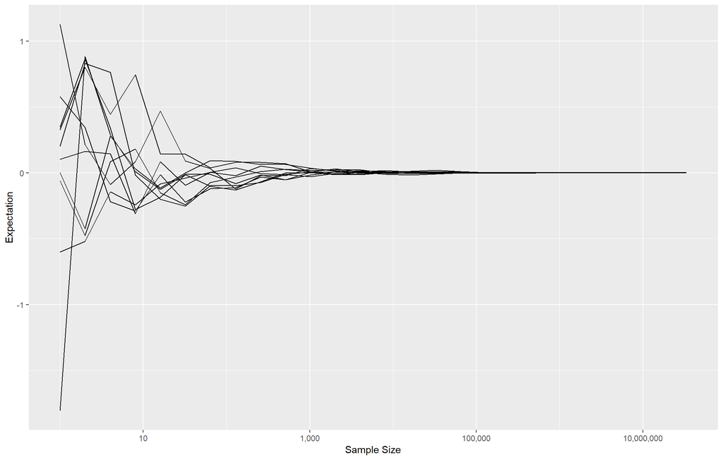

```r
calc_expect <- function(size, x_vals, func) {
    x_vals[1:size] %>% func() %>% mean()
}

y_id_vals <- map_dbl(N, calc_expect, x_vals = x_vals, func = function(x) x)
y_sq_vals <- map_dbl(N, calc_expect, x_vals = x_vals, func = function(x) x*x)


n_iter <- 10

sim_id_tbl <- rerun(n_iter
                   ,tibble(size = N
                          ,vals = map_dbl(N
                                         ,calc_expect
                                         ,x_vals = rnorm(max(N), 0, 1)
                                         ,func = function(x) x))) %>%
    bind_rows(.id = 'sim_id')

ggplot(sim_id_tbl) +
    geom_line(aes(x = size, y = vals, group = sim_id)) +
    scale_x_log10(labels = comma) +
    xlab('Sample Size') +
    ylab('Expectation')
```

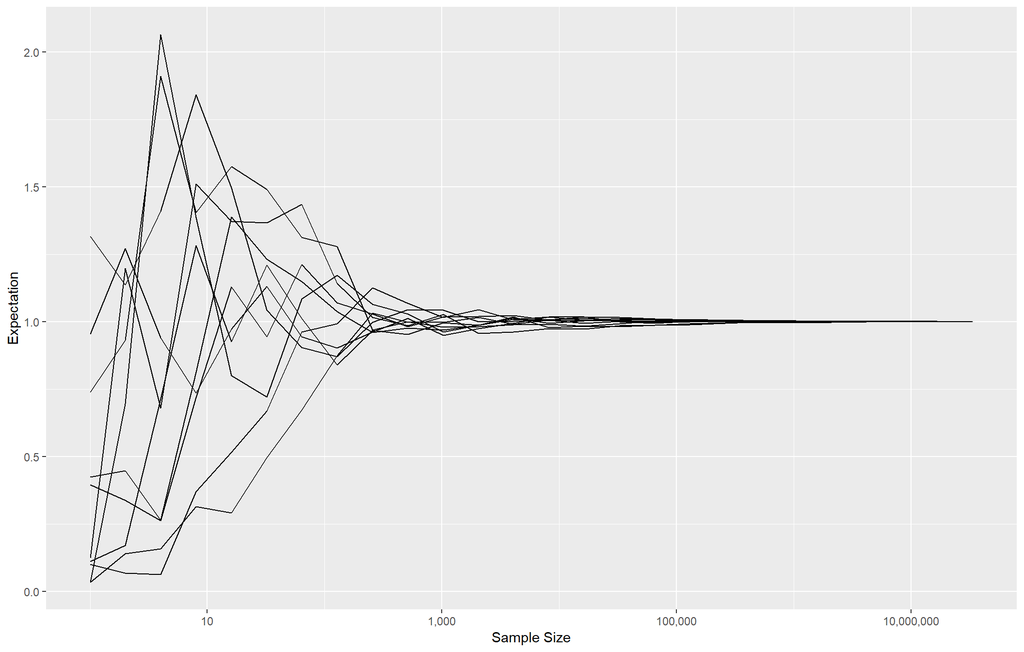

```r
sim_sq_tbl <- rerun(n_iter
                   ,tibble(size = N
                          ,vals = map_dbl(N
                                         ,calc_expect
                                         ,x_vals = rnorm(max(N), 0, 1)
                                         ,func = function(x) x*x))) %>%
    bind_rows(.id = 'sim_id')

ggplot(sim_sq_tbl) +
    geom_line(aes(x = size, y = vals, group = sim_id)) +
    scale_x_log10(labels = comma) +
    xlab('Sample Size') +
    ylab('Expectation')
```

## 1.1 Uniform Distribution

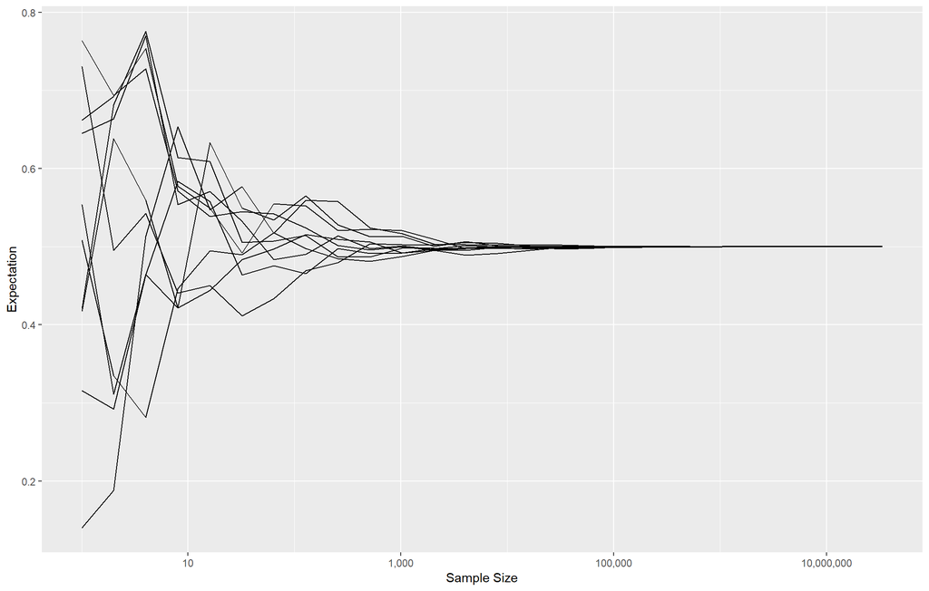

```r
sim_id_tbl <- rerun(n_iter
                   ,tibble(size = N
                          ,vals = map_dbl(N
                                         ,calc_expect
                                         ,x_vals = runif(max(N), 0, 1)
                                         ,func = function(x) x))) %>%
    bind_rows(.id = 'sim_id')

ggplot(sim_id_tbl) +
    geom_line(aes(x = size, y = vals, group = sim_id)) +
    scale_x_log10(labels = comma) +
    xlab('Sample Size') +
    ylab('Expectation')
```

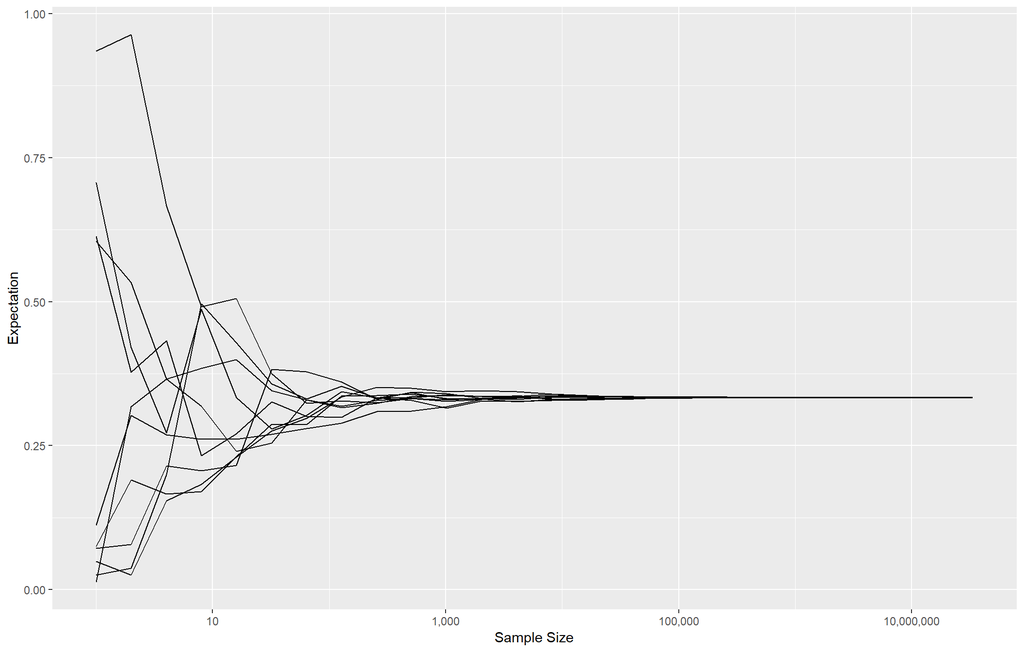

```r
sim_sq_tbl <- rerun(n_iter
                   ,tibble(size = N
                          ,vals = map_dbl(N
                                         ,calc_expect
                                         ,x_vals = runif(max(N), 0, 1)
                                         ,func = function(x) x*x))) %>%
    bind_rows(.id = 'sim_id')

ggplot(sim_sq_tbl) +
    geom_line(aes(x = size, y = vals, group = sim_id)) +
    scale_x_log10(labels = comma) +
    xlab('Sample Size') +
    ylab('Expectation')
```

## 1.2 Cauchy Distribution

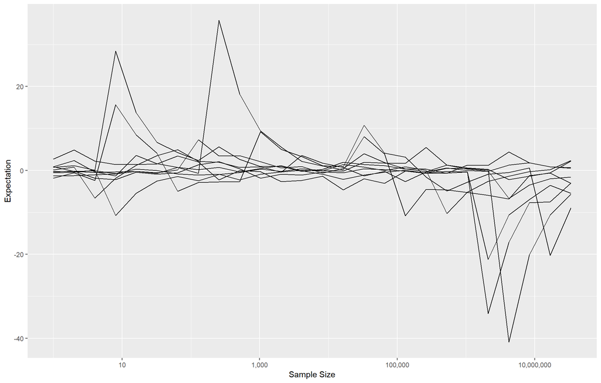

```r
sim_id_tbl <- rerun(n_iter
   ,tibble(size = N
          ,vals = map_dbl(N
                         ,calc_expect
                         ,x_vals      = rcauchy(max(N), 0, 1)
                         ,func        = function(x) x))) %>%
    bind_rows(.id = 'sim_id')

ggplot(sim_id_tbl) +
    geom_line(aes(x = size, y = vals, group = sim_id)) +
    scale_x_log10(labels = comma) +
    xlab('Sample Size') +
    ylab('Expectation')
```

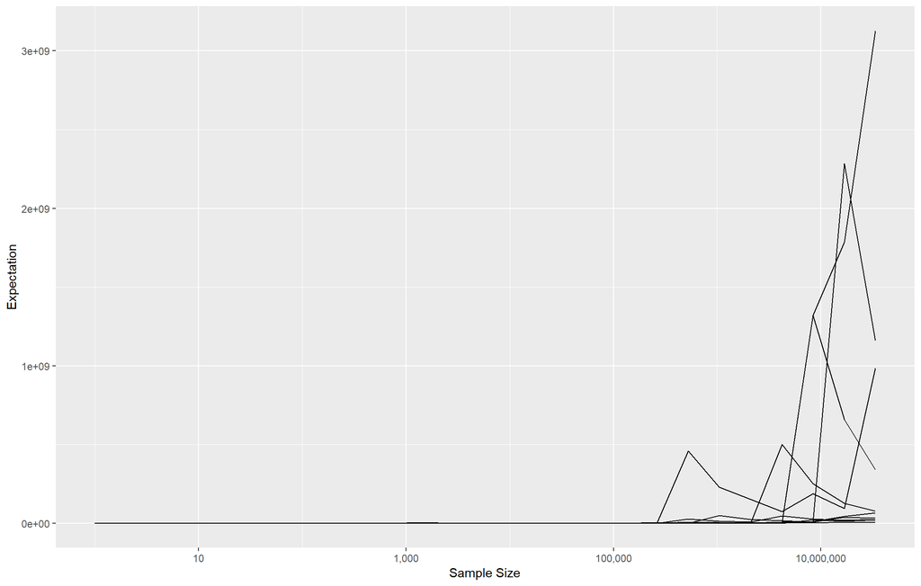

```r
sim_sq_tbl <- rerun(n_iter
    ,tibble(size = N
           ,vals = map_dbl(N
                          ,calc_expect
                          ,x_vals      = rcauchy(max(N), 0, 1)
                          ,func        = function(x) x*x))) %>%
    bind_rows(.id = 'sim_id')

ggplot(sim_sq_tbl) +
    geom_line(aes(x = size, y = vals, group = sim_id)) +
    scale_x_log10(labels = comma) +
    xlab('Sample Size') +
    ylab('Expectation')
```

# 2 Expected Value

## 2.1 1D6

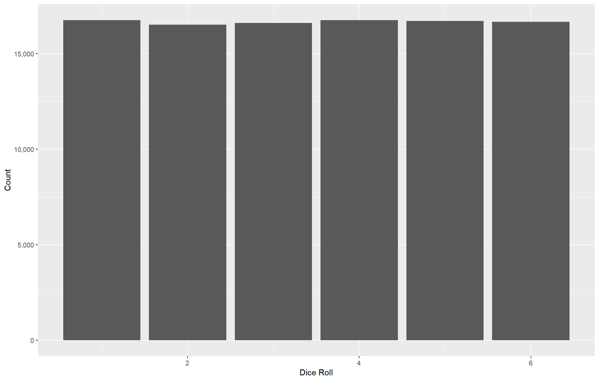

```r
n_roll <- 100000

onedice <- sample(1:6, n_roll, replace = TRUE)

ggplot(tibble(dice = onedice)) +
    geom_bar(aes(x = dice)) +
    scale_y_continuous(labels = comma) +
    xlab("Dice Roll") +
    ylab("Count")
```

```r
mean(onedice)
```

```
## [1] 3.50122
```

## 2.2 2D6

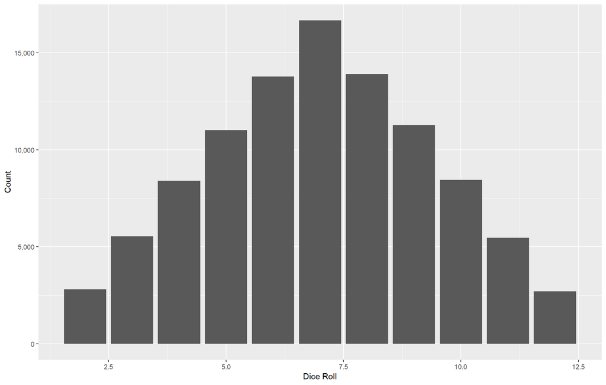

```r
twodice_indiv <- matrix(sample(1:6, 2 * n_roll, replace = TRUE), ncol = 2)
twodice <- rowSums(twodice_indiv)

ggplot(tibble(dice = twodice)) +
    geom_bar(aes(x = dice)) +
    scale_y_continuous(labels = comma) +
    xlab("Dice Roll") +
    ylab("Count")
```

```r
mean(twodice)
```

```
## [1] 6.99962
```

## 2.3 3D6

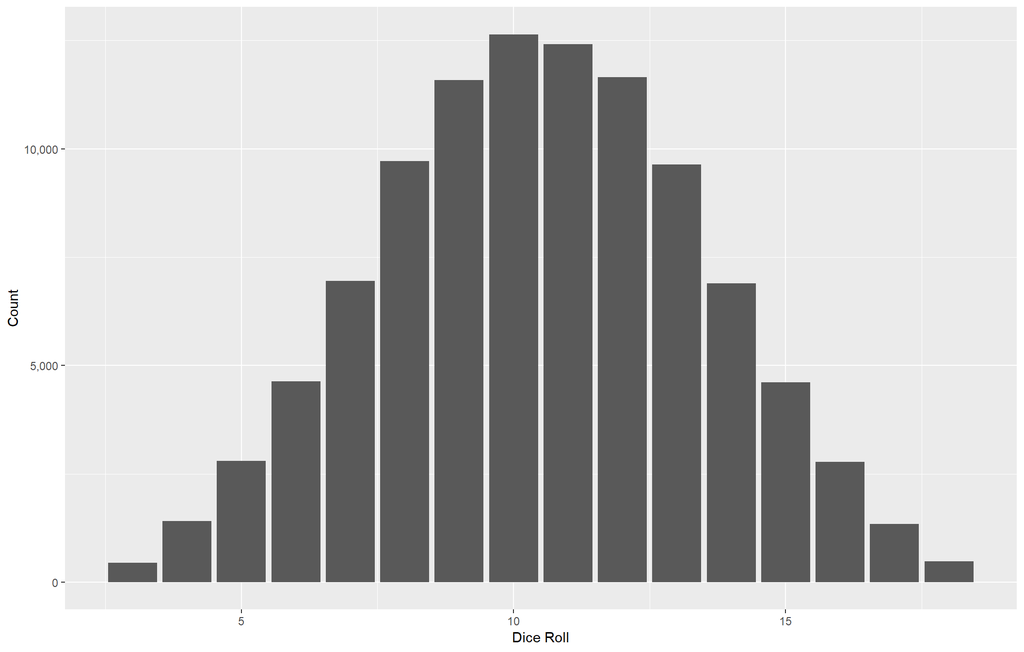

```r
threedice_indiv <- matrix(sample(1:6, 3 * n_roll, replace = TRUE), ncol = 3)
threedice <- rowSums(threedice_indiv)

ggplot(tibble(dice = threedice)) +
    geom_bar(aes(x = dice)) +
    scale_y_continuous(labels = comma) +
    xlab("Dice Roll") +
    ylab("Count")
```

```r
mean(threedice)
```

```
## [1] 10.4917
```

## 2.4 4D6 - Drop Lowest

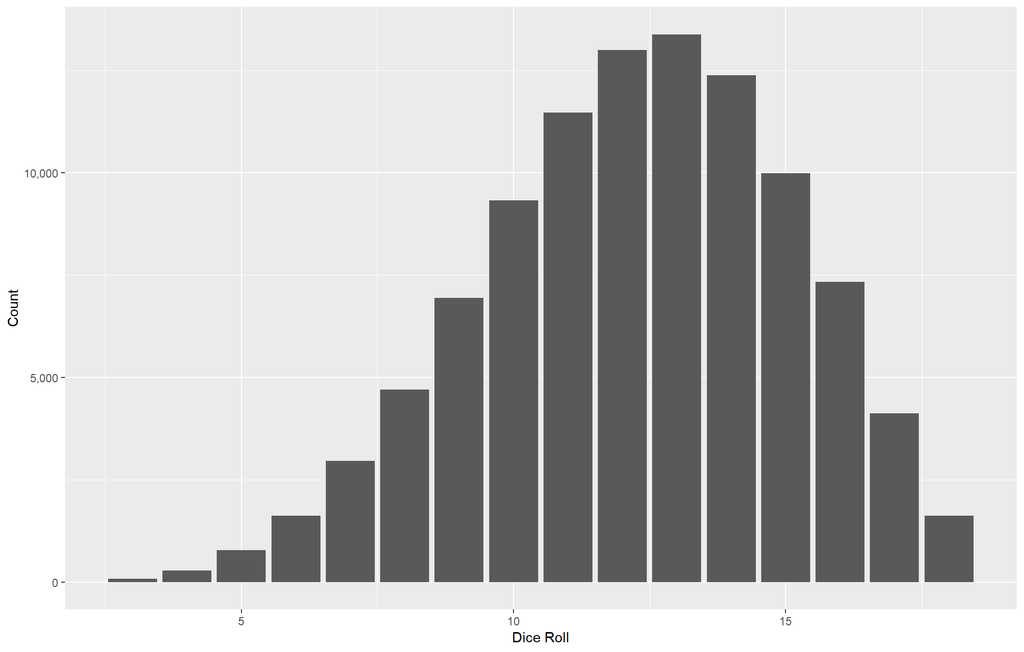

```r
drop_lowest <- function(x) x %>% sort(decreasing = TRUE) %>% .[1:3] %>% sum()

topthree_indiv <- matrix(sample(1:6, 4 * n_roll, replace = TRUE), ncol = 4)
topthree <- apply(topthree_indiv, 1, drop_lowest)

ggplot(tibble(dice = topthree)) +
    geom_bar(aes(x = dice)) +
    scale_y_continuous(labels = comma) +
    xlab("Dice Roll") +
    ylab("Count")
```

```r
mean(topthree)
```

```
## [1] 12.2492
```

## 2.5 5D6 - Drop Extremes

What if we roll 5d6 and drop both the highest and lowest result - how does this compare to the 3d6 rolls?

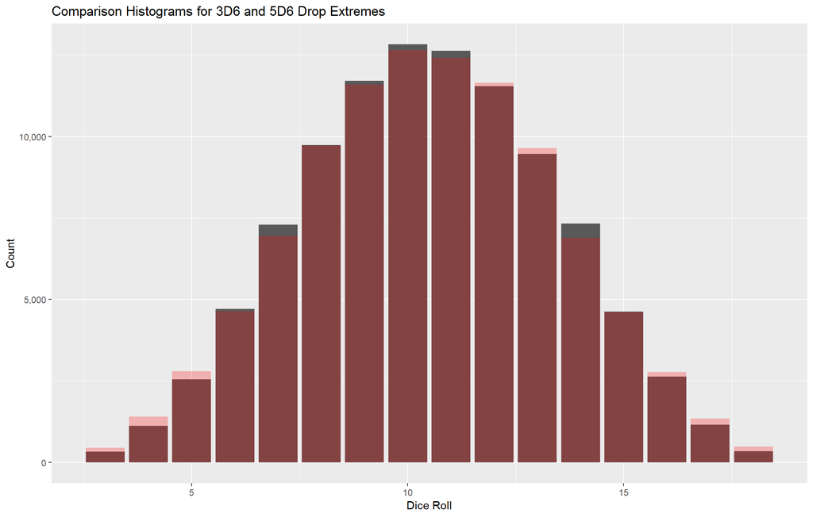

```r
drop_extreme <- function(x) x %>% sort() %>% .[2:4] %>% sum()

five_dice <- matrix(sample(1:6, 5 * n_roll, replace = TRUE), ncol = 5)
fivethree <- apply(five_dice, 1, drop_extreme)

ggplot(tibble(dice = fivethree, orig = threedice)) +
    geom_bar(aes(x = dice)) +
    geom_bar(aes(x = threedice), alpha = 0.25, fill = 'red') +
    scale_y_continuous(labels = comma) +
    xlab("Dice Roll") +
    ylab("Count") +
    ggtitle("Comparison Histograms for 3D6 and 5D6 Drop Extremes")
```

```r
mean(fivethree)
```

```
## [1] 10.4947
```

# 3 Bayes Rule

A disease affects 1 in 1,000 people. A test for the disease exists, and gives a positive result 99% of the time when performed on a sick patient. If the person is not sick, it has a false alarm rate of 5%.

Given a person tests positive, what is the probability of the person being sick?

```r
n_sim <- 1000000

base_rate <- 0.001
true_rate <- 0.99
fa_rate   <- 0.05

data_tbl <- tibble(id = 1:n_sim) %>%
    mutate(sick_person = sample(c(TRUE, FALSE)
                               ,n_sim
                               ,prob = c(base_rate, 1 - base_rate)
                               ,replace = TRUE))

sick_tbl    <- data_tbl %>% filter(sick_person == TRUE)
notsick_tbl <- data_tbl %>% filter(sick_person == FALSE)

sick_tbl <- sick_tbl %>%
    mutate(test_result = sample(c(TRUE, FALSE)
                               ,n()
                               ,prob = c(true_rate, 1 - true_rate)
                               ,replace = TRUE))

notsick_tbl <- notsick_tbl %>%
    mutate(test_result = sample(c(TRUE, FALSE)
                               ,n()
                               ,prob = c(fa_rate, 1 - fa_rate)
                               ,replace = TRUE))


data_tbl <- list(sick_tbl, notsick_tbl) %>%
    bind_rows() %>%
    arrange(id)
```

- How many people are sick?
- How many people test positive?
- Of the people with a positive result, how many are actually sick?

```r
data_tbl %>% filter(sick_person == TRUE) %>% nrow()
```

```
## [1] 1010
```

```r
data_tbl %>% filter(test_result == TRUE) %>% nrow()
```

```
## [1] 51225
```

```r
data_tbl %>%
    filter(test_result == TRUE) %>%
    summarise(n_sick = sum(sick_person), sick_prop = n_sick / n())
```

```
## # A tibble: 1 x 2
##   n_sick sick_prop
##    <int>     <dbl>
## 1    993    0.0194
```

How does this depend on the false alarm rate?

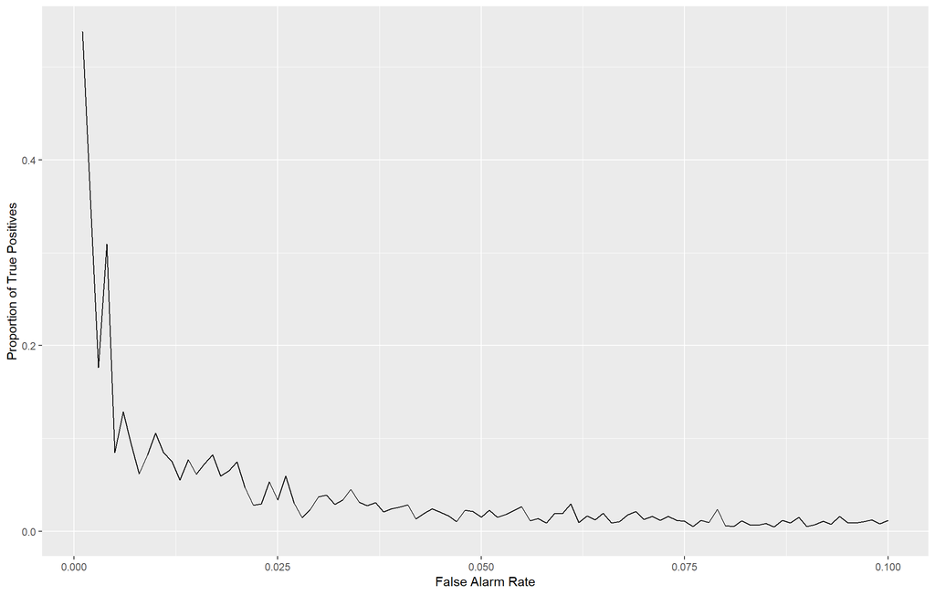

```r
create_medtest_data <- function(n_sim = 1e6, base_rate = 0.001, true_rate = 0.99, fa_rate = 0.05) {
    data_tbl <- tibble(id = 1:n_sim) %>%
    mutate(sick_person = sample(c(TRUE, FALSE)
                               ,n_sim
                               ,prob = c(base_rate, 1 - base_rate)
                               ,replace = TRUE))

    sick_tbl    <- data_tbl %>% filter(sick_person == TRUE)
    notsick_tbl <- data_tbl %>% filter(sick_person == FALSE)

    sick_tbl <- sick_tbl %>%
        mutate(test_result = sample(c(TRUE, FALSE)
                                   ,n()
                                   ,prob = c(true_rate, 1 - true_rate)
                                   ,replace = TRUE))

    notsick_tbl <- notsick_tbl %>%
        mutate(test_result = sample(c(TRUE, FALSE)
                                   ,n()
                                   ,prob = c(fa_rate, 1 - fa_rate)
                                   ,replace = TRUE))

    data_tbl <- list(sick_tbl, notsick_tbl) %>%
        bind_rows() %>%
        arrange(id)

    return(data_tbl)
}

fa_vals <- seq(0.001, 0.10, by = 0.001)

sick_prop <- map_dbl(fa_vals, function(fa) create_medtest_data(10000
                                                              ,base_rate = 0.001
                                                              ,true_rate = 0.99
                                                              ,fa_rate   = fa) %>%
            filter(test_result == TRUE) %>%
            summarise(sick_prop = sum(sick_person) / n()) %>%
            pull(sick_prop)
        )

ggplot() +
    geom_line(aes(x = fa_vals, y = sick_prop)) +
    expand_limits(y = 0) +
    xlab('False Alarm Rate') +
    ylab('Proportion of True Positives')
```

What if we have multiple tests?

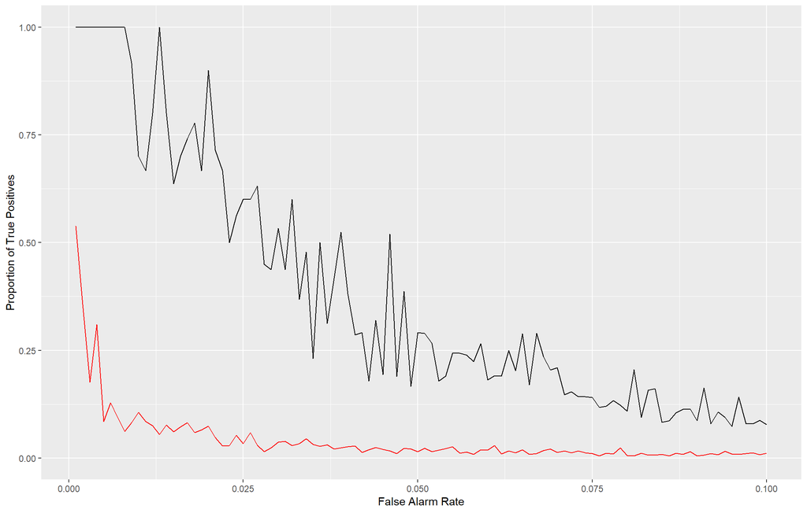

```r
create_two_medtest_data <- function(n_sim = 1e6, base_rate = 0.001, true_rate = 0.99, fa_rate = 0.05) {
    data_tbl <- tibble(id = 1:n_sim) %>%
    mutate(sick_person = sample(c(TRUE, FALSE)
                               ,n_sim
                               ,prob = c(base_rate, 1 - base_rate)
                               ,replace = TRUE))

    sick_tbl    <- data_tbl %>% filter(sick_person == TRUE)
    notsick_tbl <- data_tbl %>% filter(sick_person == FALSE)

    sick_tbl <- sick_tbl %>%
        mutate(test_result_1 = sample(c(TRUE, FALSE)
                                     ,n()
                                     ,prob = c(true_rate, 1 - true_rate)
                                     ,replace = TRUE)
              ,test_result_2 = sample(c(TRUE, FALSE)
                                     ,n()
                                     ,prob = c(true_rate, 1 - true_rate)
                                     ,replace = TRUE)
               )

    notsick_tbl <- notsick_tbl %>%
        mutate(test_result_1 = sample(c(TRUE, FALSE)
                                     ,n()
                                     ,prob = c(fa_rate, 1 - fa_rate)
                                     ,replace = TRUE)
              ,test_result_2 = sample(c(TRUE, FALSE)
                                     ,n()
                                     ,prob = c(fa_rate, 1 - fa_rate)
                                     ,replace = TRUE)
               )

    data_tbl <- list(sick_tbl, notsick_tbl) %>%
        bind_rows() %>%
        arrange(id)

    return(data_tbl)
}

fa_vals <- seq(0.001, 0.10, by = 0.001)

sick_2_prop <- map_dbl(fa_vals
                      ,function(fa) create_two_medtest_data(10000
                                                           ,base_rate = 0.001
                                                           ,true_rate = 0.99
                                                           ,fa_rate = fa) %>%
        filter(test_result_1 == TRUE, test_result_2 == TRUE) %>%
        summarise(sick_prop = sum(sick_person) / n()) %>%
        pull(sick_prop)
    )

ggplot() +
    geom_line(aes(x = fa_vals, y = sick_prop), colour = 'red') +
    geom_line(aes(x = fa_vals, y = sick_2_prop)) +
    expand_limits(y = 0) +
    xlab('False Alarm Rate') +
    ylab('Proportion of True Positives')
```

# 4 Curse of Dimensionality

The “no-one is average” principle

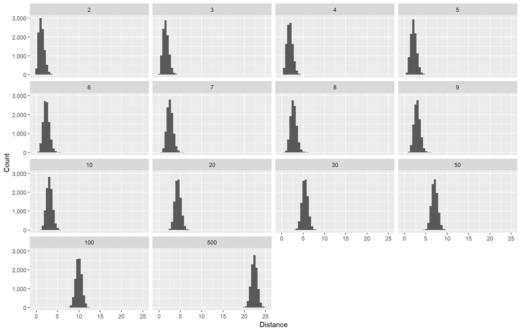

```r
dim_vals <- c(2:10, 20, 30, 50, 100, 500)

n_samples <- 10000
n_dim     <- max(dim_vals)

data_sample <- matrix(rnorm(n_dim * n_samples, 0, 1), n_samples, n_dim)

calc_norms <- function(i) apply(data_sample[, 1:i], 1, function(x) sqrt(sum(x * x)))

norms <- map(dim_vals, calc_norms)

plot_tbl <- tibble(dist = norms) %>%
    mutate(size = dim_vals) %>%
    unnest()

ggplot(plot_tbl) +
    geom_histogram(aes(x = dist), bins = 50) +
    facet_wrap(~size) +
    scale_y_continuous(labels = comma) +
    xlab("Distance") +
    ylab("Count")
```

Distance matrix gets large quickly, so just going to sample the average distances.

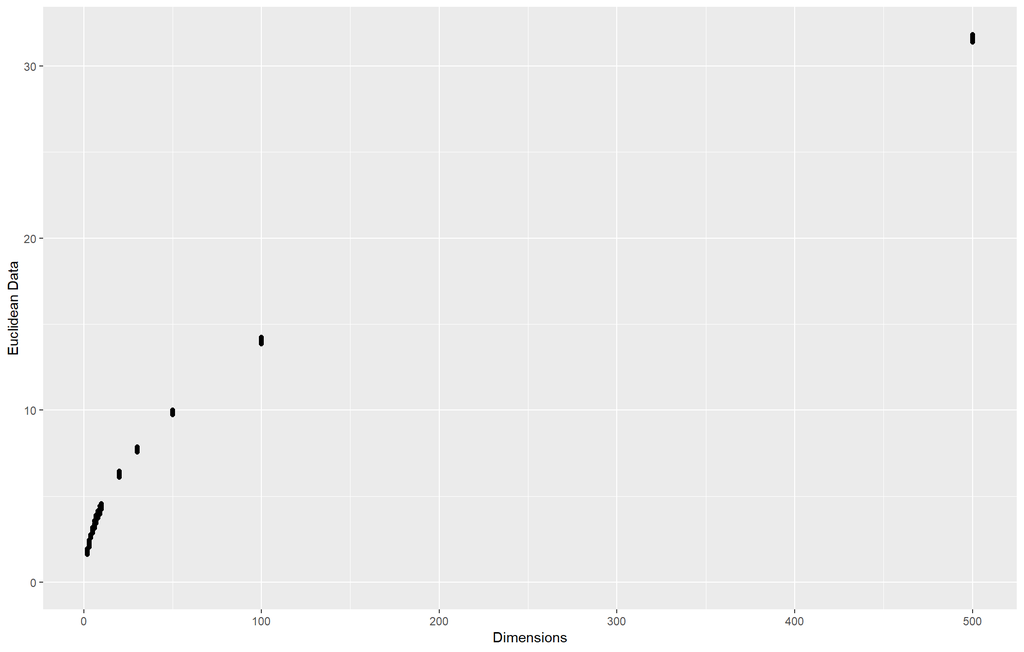

```r
calc_avg_dist <- function(samp_points, n_iter = 100) {
    idx <- sample(1:n_samples, n_iter, replace = TRUE)

    dists <- samp_points[idx,] %>% dist %>% as.vector

    return(mean(dists))
}

mean_dists_tbl <- rerun(20, tibble(size = dim_vals) %>%
    mutate(dist = map_dbl(dim_vals
                         ,function(i) calc_avg_dist(data_sample[,1:i], 100)))
    ) %>%
    bind_rows()

ggplot(mean_dists_tbl) +
    geom_point(aes(x = size, y = dist)) +
    expand_limits(y = 0) +
    xlab("Dimensions") +
    ylab("Euclidean Data")
```

How much of a unit sphere is in the unit cube?

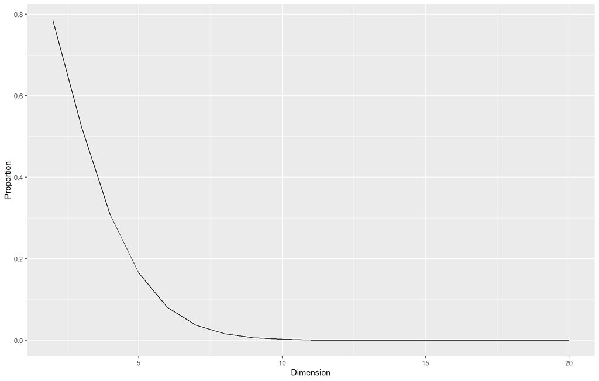

```r
n_dim     <- 20
n_samples <- 1000000

data_unitcube <- matrix(runif(n_dim * n_samples, 0, 1), n_samples, n_dim)

calc_sphere_prop <- function(i) {
    data_mat <- data_unitcube[,1:i]

    dists <- apply(data_mat, 1, function(x) sqrt(sum(x * x)))

    return(length(dists[dists <= 1]) / length(dists))
}


sphere_prop <- map_dbl(2:n_dim, calc_sphere_prop)

ggplot() +
    geom_line(aes(x = 2:n_dim, y = sphere_prop)) +
    expand_limits(y = 0) +
    xlab("Dimension") +
    ylab("Proportion")
```

# 5 Central Limit Theorem

## 5.1 Normal Distribution

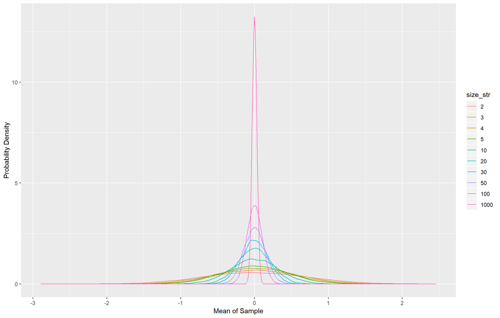

```r
clt_count <- c(2, 3, 4, 5, 10, 20, 30, 50, 100, 1000)

n_samples <- 10000
n_dim     <- max(clt_count)

data_clt <- matrix(rnorm(n_dim * n_samples, 0, 1), n_samples, n_dim)

clt_norm_data_tbl <- tibble(vals = map(clt_count, function(i) rowMeans(data_clt[,1:i]))) %>%
    mutate(size     = clt_count
          ,size_str = factor(clt_count)
           ) %>%
    unnest()


ggplot(clt_norm_data_tbl) +
    geom_line(aes(x = vals, colour = size_str), stat = 'density') +
    xlab("Mean of Sample") +
    ylab("Probability Density")
```

```r
clt_norm_data_tbl %>%
    group_by(size) %>%
    summarise(mean_val = mean(vals), sd_vals = sd(vals)) %>%
    ungroup %>%
    mutate(clt_sd = 1 / sqrt(size))
```

```
## # A tibble: 10 x 4
##     size  mean_val sd_vals clt_sd
##    <dbl>     <dbl>   <dbl>  <dbl>
##  1     2 0.0105     0.697  0.707
##  2     3 0.0139     0.572  0.577
##  3     4 0.0114     0.497  0.5
##  4     5 0.00784    0.446  0.447
##  5    10 0.00244    0.320  0.316
##  6    20 0.00174    0.224  0.224
##  7    30 0.0000868  0.182  0.183
##  8    50 0.000513   0.141  0.141
##  9   100 0.000836   0.1000 0.1
## 10  1000 0.000308   0.0316 0.0316
```

## 5.2 Uniform Distribution

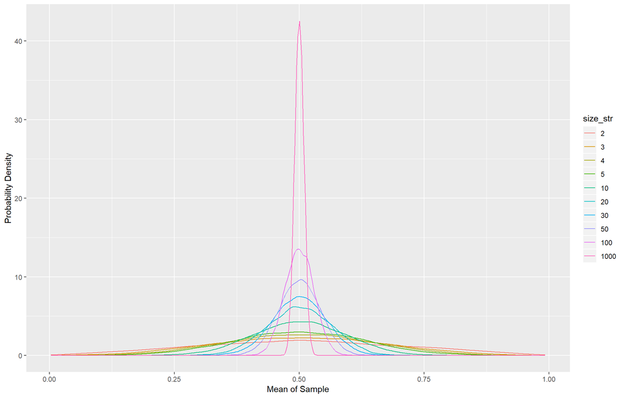

```r
clt_count <- c(2, 3, 4, 5, 10, 20, 30, 50, 100, 1000)

n_samples <- 10000
n_dim     <- max(clt_count)

data_clt <- matrix(runif(n_dim * n_samples, 0, 1), n_samples, n_dim)

clt_unif_data_tbl <- tibble(vals = map(clt_count, function(i) rowMeans(data_clt[,1:i]))) %>%
    mutate(size     = clt_count
          ,size_str = factor(clt_count)
           ) %>%
    unnest()


ggplot(clt_unif_data_tbl) +
    geom_line(aes(x = vals, colour = size_str), stat = 'density') +
    xlab("Mean of Sample") +
    ylab("Probability Density")
```

```r
clt_unif_data_tbl %>%
    group_by(size) %>%
    summarise(mean_val = mean(vals), sd_vals = sd(vals)) %>%
    ungroup %>%
    mutate(clt_sd = 1 / sqrt(12 * size))
```

```
## # A tibble: 10 x 4
##     size mean_val sd_vals  clt_sd
##    <dbl>    <dbl>   <dbl>   <dbl>
##  1     2    0.503 0.204   0.204
##  2     3    0.500 0.166   0.167
##  3     4    0.500 0.143   0.144
##  4     5    0.499 0.129   0.129
##  5    10    0.500 0.0906  0.0913
##  6    20    0.500 0.0639  0.0645
##  7    30    0.500 0.0527  0.0527
##  8    50    0.500 0.0408  0.0408
##  9   100    0.500 0.0287  0.0289
## 10  1000    0.500 0.00917 0.00913
```

## 5.3 Poisson Distribution

### 5.3.1 Low Rate

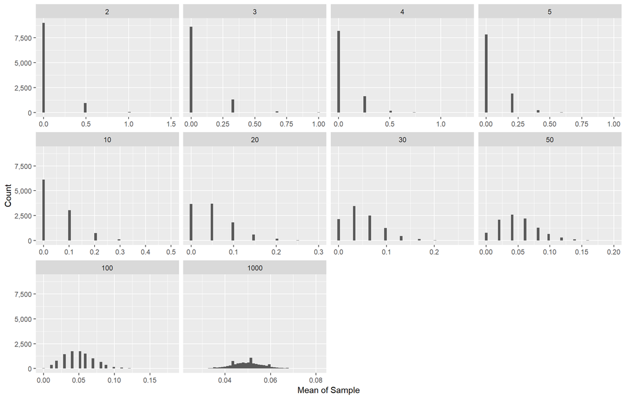

```r
clt_count <- c(2, 3, 4, 5, 10, 20, 30, 50, 100, 1000)

n_samples <- 10000
n_dim     <- max(clt_count)


data_clt <- matrix(rpois(n_dim * n_samples, 0.05), n_samples, n_dim)

clt_lowpois_data_tbl <- tibble(vals = map(clt_count, function(i) rowMeans(data_clt[,1:i]))) %>%
    mutate(size     = clt_count
          ,size_str = factor(clt_count)
           ) %>%
    unnest()


ggplot(clt_lowpois_data_tbl) +
    geom_histogram(aes(x = vals), bins = 50) +
    facet_wrap(~size, scales = 'free_x') +
    scale_y_continuous(labels = comma) +
    xlab("Mean of Sample") +
    ylab("Count")
```

```r
clt_lowpois_data_tbl %>%
    group_by(size) %>%
    summarise(mean_val = mean(vals), sd_vals = sd(vals)) %>%
    ungroup %>%
    mutate(clt_sd = sqrt(0.05) / sqrt(size))
```

```
## # A tibble: 10 x 4
##     size mean_val sd_vals  clt_sd
##    <dbl>    <dbl>   <dbl>   <dbl>
##  1     2   0.0516 0.160   0.158
##  2     3   0.0503 0.129   0.129
##  3     4   0.0502 0.113   0.112
##  4     5   0.0489 0.0995  0.10
##  5    10   0.0491 0.0696  0.0707
##  6    20   0.0500 0.0499  0.0500
##  7    30   0.0499 0.0403  0.0408
##  8    50   0.0501 0.0315  0.0316
##  9   100   0.0501 0.0223  0.0224
## 10  1000   0.0500 0.00704 0.00707
```

### 5.3.2 Medium Rate

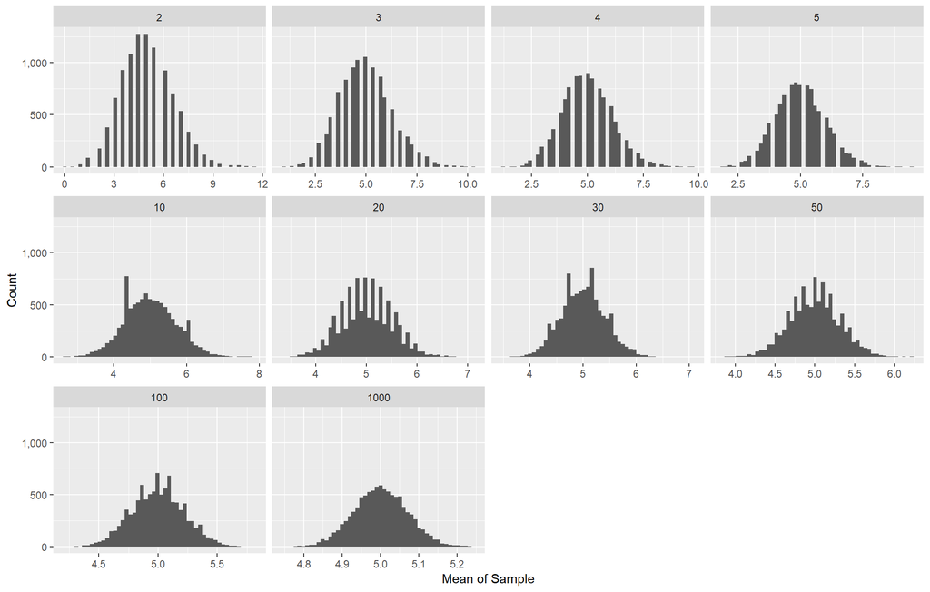

```r
clt_count <- c(2, 3, 4, 5, 10, 20, 30, 50, 100, 1000)

n_samples <- 10000
n_dim     <- max(clt_count)

count_rate <- 5


data_clt <- matrix(rpois(n_dim * n_samples, count_rate), n_samples, n_dim)

clt_lowpois_data_tbl <- tibble(vals = map(clt_count, function(i) rowMeans(data_clt[,1:i]))) %>%
    mutate(size     = clt_count
          ,size_str = factor(clt_count)
           ) %>%
    unnest()


ggplot(clt_lowpois_data_tbl) +
    geom_histogram(aes(x = vals), bins = 50) +
    facet_wrap(~size, scales = 'free_x') +
    scale_y_continuous(labels = comma) +
    xlab("Mean of Sample") +
    ylab("Count")
```

```r
clt_lowpois_data_tbl %>%
    group_by(size) %>%
    summarise(mean_val = mean(vals), sd_vals = sd(vals)) %>%
    ungroup %>%
    mutate(clt_sd = sqrt(0.05) / sqrt(size))
```

```
## # A tibble: 10 x 4
##     size mean_val sd_vals  clt_sd
##    <dbl>    <dbl>   <dbl>   <dbl>
##  1     2     4.98  1.57   0.158
##  2     3     4.99  1.29   0.129
##  3     4     4.99  1.12   0.112
##  4     5     5.00  1.00   0.10
##  5    10     5.00  0.702  0.0707
##  6    20     5.00  0.498  0.0500
##  7    30     5.00  0.409  0.0408
##  8    50     5.00  0.313  0.0316
##  9   100     5.00  0.222  0.0224
## 10  1000     5.00  0.0706 0.00707
```

### 5.3.3 High Rate

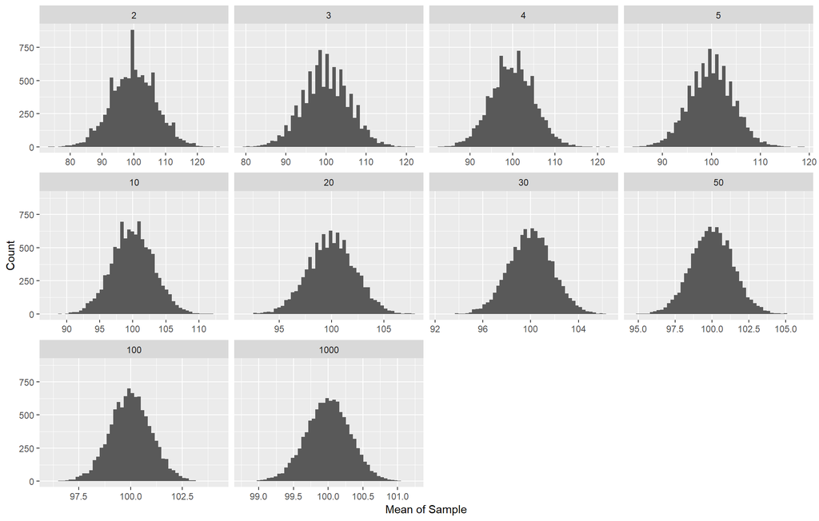

```r
clt_count <- c(2, 3, 4, 5, 10, 20, 30, 50, 100, 1000)

n_samples <- 10000
n_dim     <- max(clt_count)

count_rate <- 100


data_clt <- matrix(rpois(n_dim * n_samples, count_rate), n_samples, n_dim)

clt_lowpois_data_tbl <- tibble(vals = map(clt_count, function(i) rowMeans(data_clt[,1:i]))) %>%
    mutate(size     = clt_count
          ,size_str = factor(clt_count)
           ) %>%
    unnest()


ggplot(clt_lowpois_data_tbl) +
    geom_histogram(aes(x = vals), bins = 50) +
    facet_wrap(~size, scales = 'free_x') +
    scale_y_continuous(labels = comma) +
    xlab("Mean of Sample") +
    ylab("Count")
```

```r
clt_lowpois_data_tbl %>%
    group_by(size) %>%
    summarise(mean_val = mean(vals), sd_vals = sd(vals)) %>%
    ungroup %>%
    mutate(clt_sd = sqrt(0.05) / sqrt(size))
```

```
## # A tibble: 10 x 4
##     size mean_val sd_vals  clt_sd
##    <dbl>    <dbl>   <dbl>   <dbl>
##  1     2    100.0   7.01  0.158
##  2     3    100.    5.77  0.129
##  3     4    100.    5.01  0.112
##  4     5    100.0   4.46  0.10
##  5    10    100.0   3.18  0.0707
##  6    20    100.0   2.25  0.0500
##  7    30    100.    1.83  0.0408
##  8    50    100.    1.43  0.0316
##  9   100    100.    1.01  0.0224
## 10  1000    100.    0.318 0.00707
```

# 6 Confidence Intervals

## 6.1 Normal Distribution: N(0,1)

We take a sample of draws from $\mathcal{N}(0, 1)$. We want to use these samples to inferences of the underlying population mean.

```r
calc_subsamp_stats <- function(i, data_matrix) {
    subsamp <- data_matrix[,1:i]

    mean <- rowMeans(subsamp)
    sd   <- rowSds(subsamp) / sqrt(i)

    return(tibble(mean = mean, sd = sd))
}

is_interval_inside <- function(x, mean, sd, mult) {
    (mean - mult * sd) < x & (mean + mult * sd) > x
}


clt_count <- c(2, 3, 4, 5, 10, 20, 30, 50, 100, 1000)

n_samples <- 100000
n_dim     <- max(clt_count)

data_confint <- matrix(rnorm(n_dim * n_samples, 0, 1), n_samples, n_dim)

confint_tbl <- tibble(size = clt_count) %>%
    mutate(data = map(size, calc_subsamp_stats, data_matrix = data_confint)) %>%
    unnest() %>%
    mutate(inside_1sd = is_interval_inside(0, mean, sd, 1)
          ,inside_2sd = is_interval_inside(0, mean, sd, 2)
           ) %>%
    group_by(size) %>%
    summarise(prop_1sd = sum(inside_1sd) / n()
             ,prop_2sd = sum(inside_2sd) / n()
              )

confint_tbl %>% print()
```

```
## # A tibble: 10 x 3
##     size prop_1sd prop_2sd
##    <dbl>    <dbl>    <dbl>
##  1     2    0.502    0.707
##  2     3    0.577    0.818
##  3     4    0.611    0.862
##  4     5    0.629    0.884
##  5    10    0.660    0.925
##  6    20    0.672    0.941
##  7    30    0.676    0.946
##  8    50    0.677    0.950
##  9   100    0.682    0.952
## 10  1000    0.682    0.954
```

# 7 p-Value

# 8 Subsampling: With vs Without Replacement

Thank You!!!

mickcooney@gmail.com

https://github.com/kaybenleroll/stats_through_simulation